# Week 9: Multi-Arm Bandit Algorithms

Dr. Rajitha M. Silva

# Introduction

The **Multi-Arm Bandit (MAB)** problem is a classic scenario in sequential decision-making. It provides an adaptive alternative to traditional A/B testing by **balancing exploration and exploitation**, allowing us to learn and optimize on the fly.

In this lecture, we apply this concept to **cricket strategy optimization** - specifically, choosing the best **opening batting pair** to maximize success rates in T20 matches.

## Key Concepts

- **Arm**: A candidate opening pair (e.g., Pair A = Player 1 + Player 2).
- **Win**: A success (e.g., pair scores more than 30 runs in Powerplay).
- **Exploration**: Trying different pairs to learn their effectiveness.
- **Exploitation**: Repeatedly using the most successful pair so far.

# Sports Scenario: Choosing a T20 Opening Pair

Suppose a cricket analyst is evaluating three opening combinations based on historical and simulated match segments:

- **Pair A**: Aggressive left-right combination
- **Pair B**: Two anchors
- **Pair C**: One explosive, one inexperienced player

Each trial is a match segment. A **“win”** is defined as the pair scoring **at least 30 runs in the Powerplay** (first 6 overs).

## Initial Results (after 50 matches each)

| Opening Pair (Arm) | Wins |
| --- | --- |
| A | 10 |
| B | 2 |
| C | 4 |

If we only exploit Pair A, we might miss out on a late bloomer like Pair C.

# Epsilon-Greedy Algorithm

The epsilon-greedy algorithm is a simple rule that decides whether to explore a new arm or exploit the current best-performing one:

What does epsilon ($\epsilon$) do?

Epsilon ($\epsilon$) is a small number between 0 and 1 that controls the degree of randomness in your decisions.

With probability $\epsilon$, the algorithm explores - it selects a random option to gather more information.

With probability 1-$\epsilon$, the algorithm exploits - it picks the option that has performed best so far.

A higher $\epsilon$ means more exploration, which is good early on; a lower $\epsilon$ means more exploitation, which is good when you’re confident in your choice.

**Algorithm Steps (Flowchart-style):**

1. Initialize wins and trials for each arm
2. For each round:
- With probability $\epsilon$: choose a random arm (exploration)
- Otherwise: choose the arm with the highest success rate so far (exploitation)
- Record result and update counts
3. Repeat for a fixed number of rounds

Importance: This method ensures the model does not over-commit to an option too early, especially when performance variability is high.

We simulate a simple **epsilon-greedy algorithm**, with `epsilon = 0.1`.

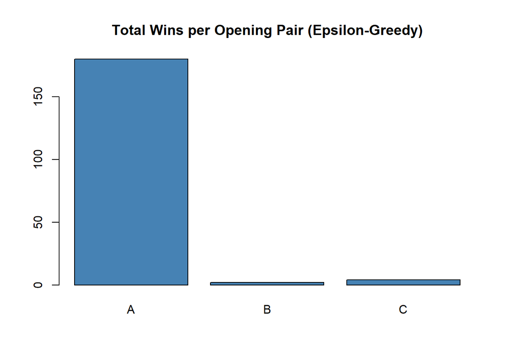

```r
set.seed(123)

# True probabilities of success (unknown in reality)
true_probs <- c(A = 0.2, B = 0.05, C = 0.08)

# Initialize
wins <- c(A = 0, B = 0, C = 0)
trials <- c(A = 0, B = 0, C = 0)
epsilon <- 0.1
n_sim <- 1000

history <- data.frame(trial = 1:n_sim, chosen = NA, result = NA)

for (i in 1:n_sim) {
  if (runif(1) < epsilon || sum(trials) == 0) {
    arm <- sample(names(true_probs), 1)
  } else {
    success_rates <- ifelse(trials == 0, 0, wins / trials)
    arm <- names(which.max(success_rates))
  }

  result <- rbinom(1, 1, true_probs[arm])
  trials[arm] <- trials[arm] + 1
  wins[arm] <- wins[arm] + result

  history$chosen[i] <- arm
  history$result[i] <- result
}

barplot(wins, main = "Total Wins per Opening Pair (Epsilon-Greedy)", col = "steelblue")
```

### Student Activity:

- Modify the `epsilon` value (e.g., try 0.01 or 0.3) and observe the impact on win counts.
- Change the success probabilities (`true_probs`) to simulate different scenarios.
- Plot running success rates (`wins/trials`) over time.